# メトロポリス・ヘイスティングス法

6/4/2021

## マルコフ連鎖: 定常分布への収束

**遷移行列\(\bf T\)を知っている状態で, どんな定常分布\(p(\cdot)\)に収束するのか求めたい.**

遷移行列

\[\begin{eqnarray} {\bf T} &=& \left( \begin{array}{ccc} p(X^{(t+1)}=紋|X^{(t)}=紋) & p(X^{(t+1)}=紋|X^{(t)}=縞) & p(X^{(t+1)}=紋|X^{(t)}=玉) \\ p(X^{(t+1)}=縞|X^{(t)}=紋) & p(X^{(t+1)}=縞|X^{(t)}=縞) & p(X^{(t+1)}=縞|X^{(t)}=玉) \\ p(X^{(t+1)}=玉|X^{(t)}=紋) & p(X^{(t+1)}=玉|X^{(t)}=縞) & p(X^{(t+1)}=玉|X^{(t)}=玉) \\ \end{array} \right) \\ \end{eqnarray}\]

マルコフ連鎖

\[\begin{eqnarray} {\bf p^{(1)}} &=& \left( \begin{array}{ccc} p(X^{(1)}=紋) & p(X^{(1)}=縞) & p(X^{(1)}=玉) \end{array} \right) \\ {\bf p^{(2)}} &=& {\bf p^{(1)}}{\bf T} \\ {\bf p^{(t+1)}} &=& {\bf p^{(t)}}{\bf T} \\ \end{eqnarray}\]

要素ごとにみると

\[\begin{eqnarray} {\bf p^{(t+1)}} &=& {\bf p^{(t)}}{\bf T} \\ p(X^{(t+1)}=紋) &=& p(X^{(t+1)}=紋|X^{(t)}=紋)p(X^{(t)}=紋) + \\ && p(X^{(t+1)}=紋|X^{(t)}=縞)p(X^{(t)}=縞) + \\ && p(X^{(t+1)}=紋|X^{(t)}=玉)p(X^{(t)}=玉) \\ p(X^{(t+1)}=j) &=& \sum_{i=1}^{3}p(X^{(t+1)}=j|X^{(t)}=i)p(X^{(t)}=i) \end{eqnarray}\]

数値例:

\[\begin{eqnarray} {\bf T} &=& \left( \begin{array}{ccc} 0.3 & 0.3 & 0.4 \\ 0.1 & 0.5 & 0.4 \\ 0.2 & 0.6 & 0.2 \end{array} \right) \\ {\bf p^{(1)}} &=& \left( \begin{array}{ccc} 0.6 & 0.25 & 0.15 \end{array} \right) \\ \end{eqnarray}\]

```
##           紋        縞        玉  t
## 1  0.6000000 0.2500000 0.1500000  1
## 2  0.2350000 0.3950000 0.3700000  2
## 3  0.1840000 0.4900000 0.3260000  3
## 4  0.1694000 0.4958000 0.3348000  4
## 5  0.1673600 0.4996000 0.3330400  5
## 6  0.1667760 0.4998320 0.3333920  6
## 7  0.1666944 0.4999840 0.3333216  7
## 8  0.1666710 0.4999933 0.3333357  8
## 9  0.1666678 0.4999994 0.3333329  9
## 10 0.1666668 0.4999997 0.3333334 10
```

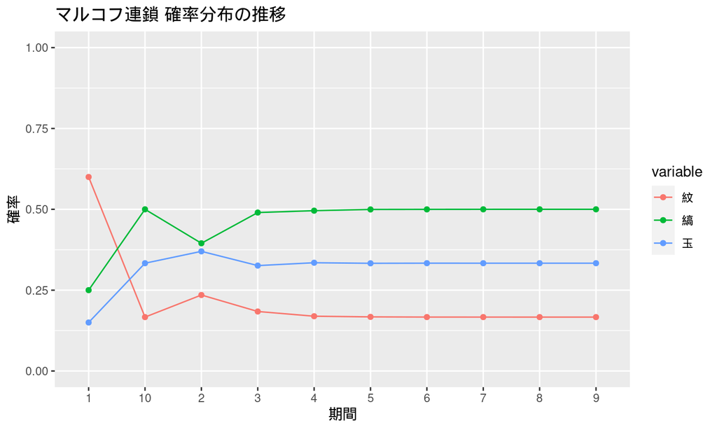

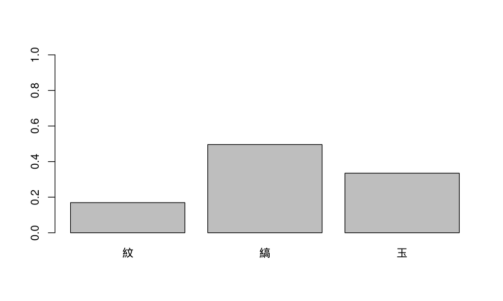

定常分布は\({\bf \bar p} = (\bar p(X=紋), \bar p(X=縞), \bar p(X=玉)) = (\frac{1}{6}, \frac{1}{2}, \frac{1}{3})\)くらいですね.

## マルコフ連鎖: 詳細釣り合い条件

**収束する先である定常分布\(\bar p(\cdot)\)を知っている状態で, どんな推移行列\(\bf T\)かを求めたい.**  
**(\(\bf T\)がわかれば, \(\bar p(\cdot)\)に従う乱数が作れる!)**

定常分布\(\bar p(\cdot)\)に収束している状態を数式で表すと,

\[\begin{eqnarray} \bar p(X'=j) &=& \sum_i {\rm Pr}(X'=j|X=i)\bar p(X=i) \ {\rm for \ all} \ j \\ (\bar p(X=i) &=& \sum_j {\rm Pr}(X=i|X'=j)\bar p(X'=j) \ {\rm for \ all} \ i) \\ なじみのある行列で書くと, \\ {\bf p^{(\infty)}} &=& {\bf p^{(\infty)}}{\bf T} \\ \end{eqnarray}\]

\[\begin{eqnarray} \overbrace{\bar p(X'=j)}^{確率分布\bar p(・)は一定} &=& \overbrace {\sum_i {\rm Pr}(X'=j|X=i)}^{未知の遷移核}\overbrace{\bar p(X=i)}^{確率分布\bar p(・)は一定} {\rm for \ all} \ j \\ 行列で表すと \\ \overset{確率分布一定}{{\bf \bar p}} &=& \overset{確率分布一定}{{\bf \bar p}} \overset{未知の遷移行列}{{\bf T}} \end{eqnarray}\]

マルコフ過程が収束するための十分条件は,

\[\begin{eqnarray} {\rm Pr}(X=i|X'=j)\bar p(X'=j) &=& {\rm Pr}(X'=j|X=i)\bar p(X=i) \\ \end{eqnarray}\]

これを**詳細釣り合い条件**といいます.

証明は以下の通りです.

\[\begin{eqnarray} {\rm Pr}(X=i|X'=j)\bar p(X'=j) &=& {\rm Pr}(X'=j|X=i)\bar p(X=i) \\ 両辺をiに関して和をとる \\ \sum_i {\rm Pr}(X=i|X'=j)\bar p(X'=j) &=& \sum_i {\rm Pr}(X'=j|X=i)\bar p(X=i) \\ \bar p(X'=j)\overbrace {\sum_i {\rm Pr}(X=i|X'=j)}^{周辺化して1} &=& \sum_i {\rm Pr}(X'=j|X=i)\bar p(X=i) \\ \bar p(X'=j) &=& \sum_i {\rm Pr}(X'=j|X=i)\bar p(X=i) \\ \end{eqnarray}\]

詳細釣り合い条件の意味は, 収束中1ステップあたりの  
「今期\(X=i\) → 1期後\(X'=j\)に遷移する量\(p(X'=j|X=i)p(X=i)\)」と 「1期前\(X'=j\) → 今期\(X=i\)に遷移する量\(p(X=i|X'=j)p(X'=j)\)」が等しい

\[\begin{eqnarray} \overbrace{{\rm Pr}(X=i|X'=j)\bar p(X'=j)}^{j \rightarrow i の移動量} &=& \overbrace{{\rm Pr}(X'=j|X=i)\bar p(X=i)}^{i \rightarrow j の移動量} \\ \end{eqnarray}\]

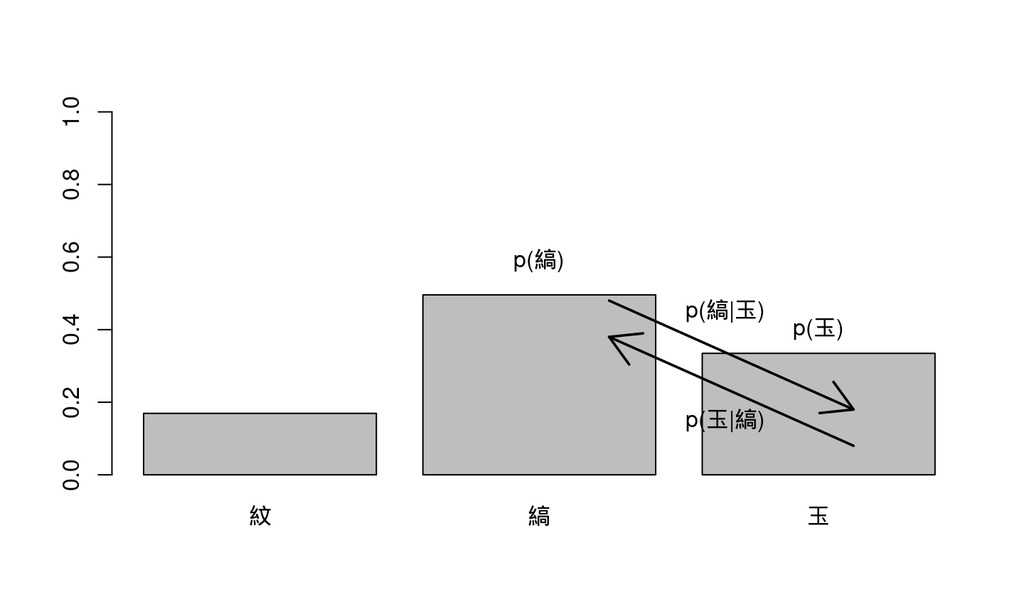

## マルコフ連鎖: 定常分布の乱数発生

- 各要素が詳細釣り合い条件\({\rm Pr}(X=i|X'=j)\bar p(X'=j) = {\rm Pr}(X'=j|X=i)\bar p(X=i)\)  
  を満たす遷移核である遷移行列\(\bf A\)を発見する.
- \(x^{(t)}\)を遷移行列\({\bf T}\)にくぐらせる(条件付確率分布\({\rm Pr}(\cdot|X=x^{(t)})\)から乱数発生する)と  
  定常分布\(\bar p(\cdot)\)に従った\(x^{(t+1)}\)が出てくる. (初期値は定義域なら何でもok)
- 更に\(x^{(t+1)}\)を遷移行列\({\bf T}\)にくぐらせると…というふうに繰り返すと,  
  定常分布\(\bar p(\cdot)\)に従った状態が乱数列\({\bf x} = \{x_0, x_1, ...\}\)が得られる.

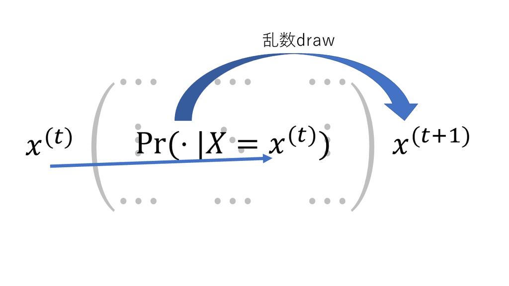

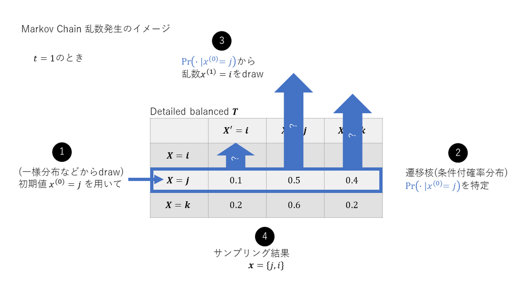

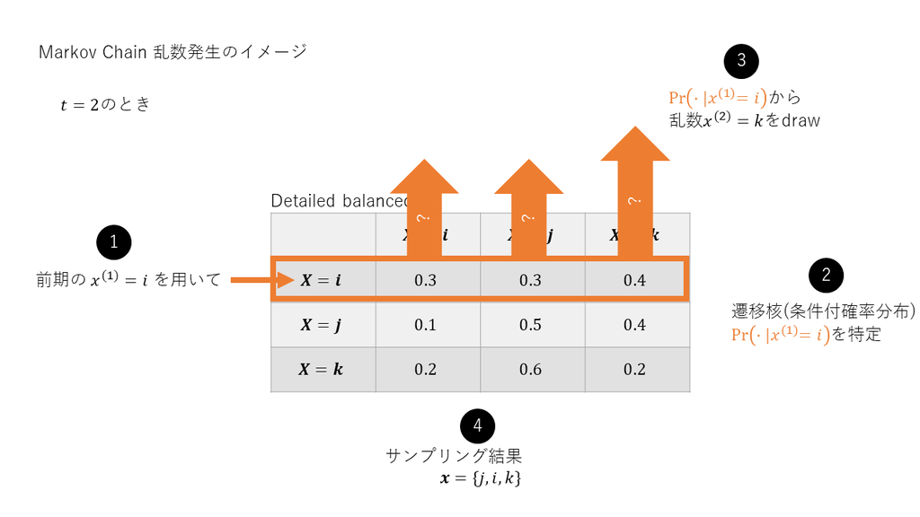

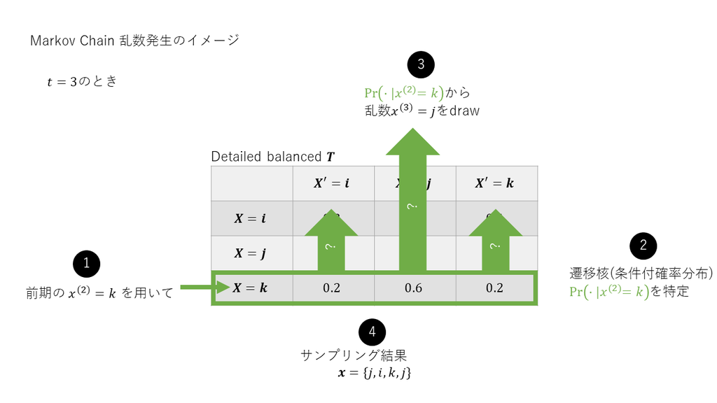

<例題>

定常分布は\({\bf \bar p} = (\frac{1}{6}, \frac{1}{2}, \frac{1}{3})\)でした. 定常分布を元に詳細釣り合い条件を満たす遷移核を何とかして見つけておきました. 確かめてみてください.

|  | 紋 | 縞 | 玉 |
| --- | --- | --- | --- |
| 紋 | 0.3 | 0.3 | 0.4 |
| 縞 | 0.1 | 0.5 | 0.4 |
| 玉 | 0.2 | 0.6 | 0.2 |

この遷移核を用いて, 定常分布に従う乱数を作ってみましょう.

```
## [1] "Generated Random Numbers"
```

[output not shown]

[output cut: 263 more lines]

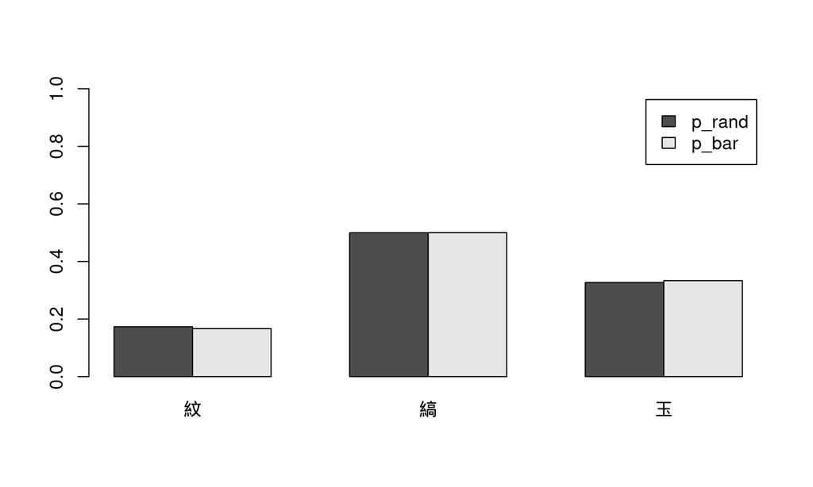

詳細釣り合い条件を満たしている遷移行列\({\bf T}\)がわからない状態で,  
どうやって定常分布にしたがう乱数を発生したらいいでしょうか?

\[\begin{eqnarray} \overbrace{{\rm Pr}(X=i|X'=j)}^{?}\bar p(X'=j) &=& \overbrace{{\rm Pr}(X'=j|X=i)}^{?}\bar p(X=i) \\ \end{eqnarray}\]

## メトロポリス・ヘイスティングス法 (Metropolis-Hastings: MH))

遷移核\({\rm Pr}(|X=i)\)からdrawする代わりに,  
適当な乱数生成が容易な分布(**提案分布**)\(q(|X=i)\)から  
乱数候補\(a^{(t+1)}\)をdrawします.  
(遷移核も, 行列\(A\)の各行で切ってみると条件付確率**分布**です)

drawした乱数候補\(a^{(t+1)}\)について, “ある基準”を満たせば採用し,  
満たさなければ破棄(マルコフ連鎖なので前の状態を維持)します.

そうやって採用と破棄を繰り返せば, 定常分布(**目的分布**)に従う乱数が作れそうです.

これがMH法のざっくりしたアイディアとなります.

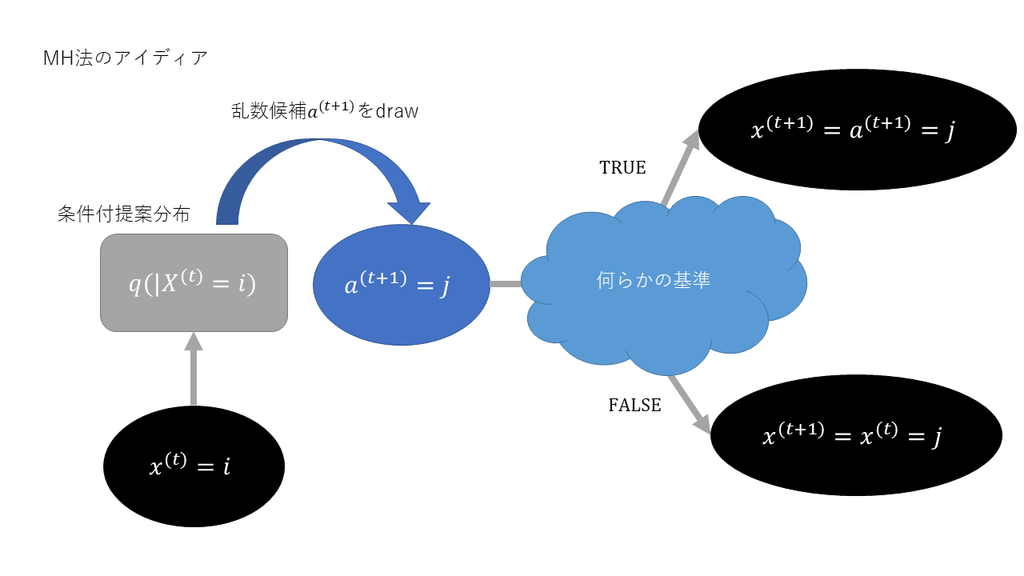

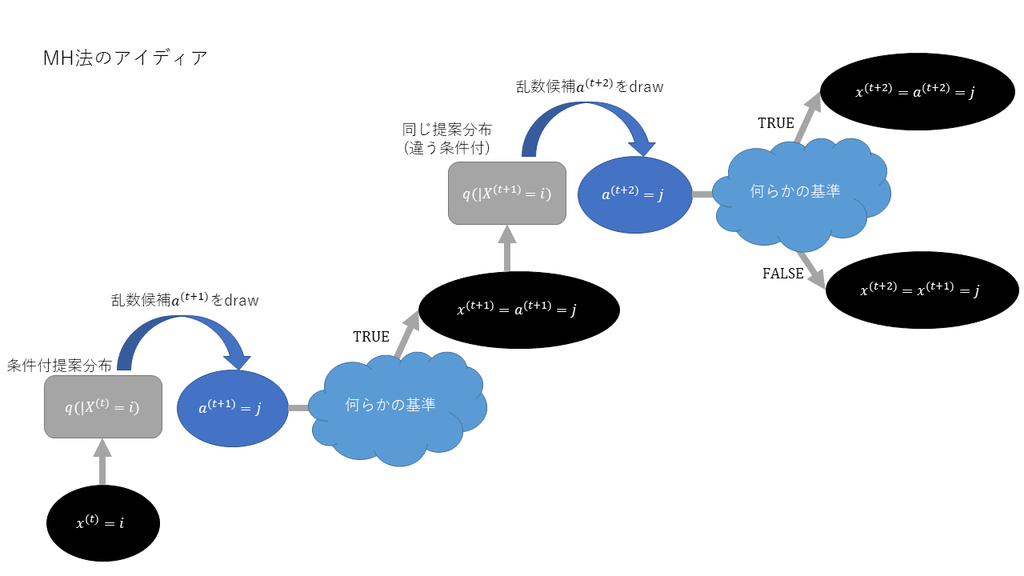

もっと正確にいうと,

drawした乱数候補\(a^{(t+1)}\)について, “ある基準”に基づいて, (マルコフ連鎖は確率的遷移なので)一定確率\(A\)で採用し, 一定確率\(1-A\)で前の状態を維持します.

このように,もとの遷移にさらに確率的な要素を加えて補正することを確率補正といいます.

それでは, MH法のポイントである“ある基準”が何なのか見てみましょう.

“ある基準”とは, 「詳細釣り合い条件が成り立つ」かどうかです.  
(遷移に詳細釣り合い条件さえ成り立てば目的の定常分布に収束するので乱数を好きなだけ作れます)

そこで詳細釣り合い条件が成り立つように以下の確率\(A(a^{(t+1)}, X^{(t)})\)で提案分布を確率補正します.

\[\begin{eqnarray} A(a^{(t+1)}, X^{(t)}) &=& \min \left(1, \frac {q(X^{(t)}|a^{(t+1)}) \bar p(a^{(t+1)})} {q(a^{(t+1)}|X^{(t)}) \bar p(X^{(t)})} \right) \\ \end{eqnarray}\]

確率\(A(a^{(t+1)}, X^{(t)})\) !順番注意! を提案分布\(q(a^{(t+1)} | X^{(t)})\)と組み合わせて確率補正すると,  
補正された遷移核\(q(a^{(t+1)} | X^{(t)}) \ A(a^{(t+1)}, X^{(t)})\)は詳細釣り合い条件を満たします.  
従って確率補正した遷移は目的の定常分布に収束します.

<証明>

\[\begin{eqnarray} q(a^{(t+1)} | X^{(t)}) \ A(a^{(t+1)}, X^{(t)}) \ \bar p(X^{(t)}) &=& q(a^{(t+1)} | X^{(t)}) \ \min \left(1, \frac {q(X^{(t)}|a^{(t+1)}) \bar p(a^{(t+1)})} {q(a^{(t+1)}|X^{(t)}) \bar p(X^{(t)})} \right) \bar p(X^{(t)}) \\ &=& \ \min \left( \ q(a^{(t+1)} \bar p(X^{(t)}) | X^{(t)}), \ q(X^{(t)}|a^{(t+1)}) \bar p(a^{(t+1)}) \ \right) \\ &=& \ q(X^{(t)}|a^{(t+1)}) \min \left( \ \frac {q(a^{(t+1)} \bar p(X^{(t)}) | X^{(t)})} {q(X^{(t)}|a^{(t+1)}) \bar p(a^{(t+1)})}, \ 1 \ \right) \bar p(a^{(t+1)}) \\ &=& \ q(X^{(t)}|a^{(t+1)}) \ A(X^{(t)}, a^{(t+1)}) \ \bar p(a^{(t+1)}) \end{eqnarray}\]

時点の前後は一般的には関係ないので, \(a^{(t+1)}=X', X^{(t)}=X\)とすると,

\[\begin{eqnarray} q(X' | X) \ A(X', X) \ \bar p(X) &=& \ q(X|X') \ A(X, X') \ \bar p(X') \end{eqnarray}\]

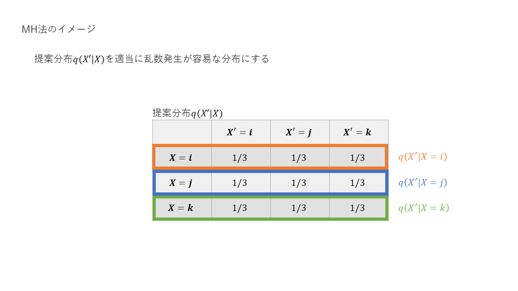

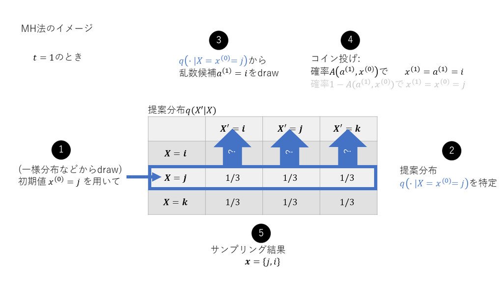

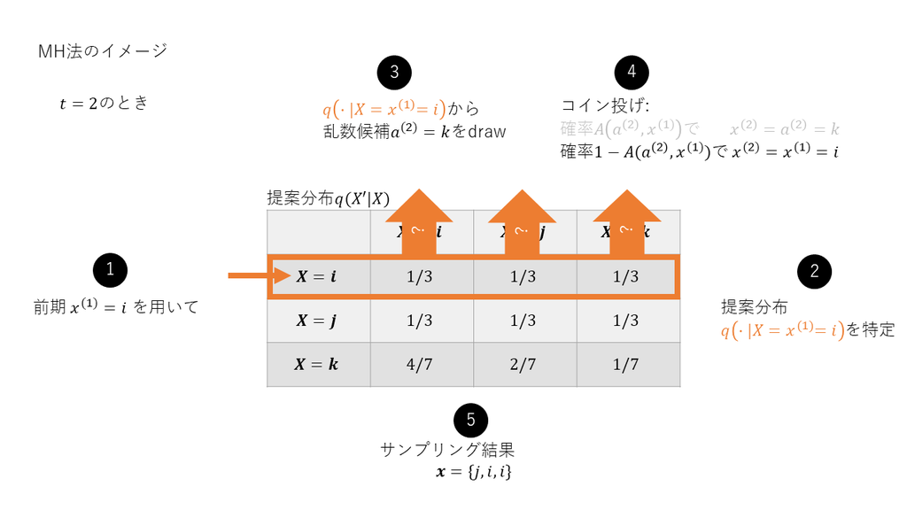

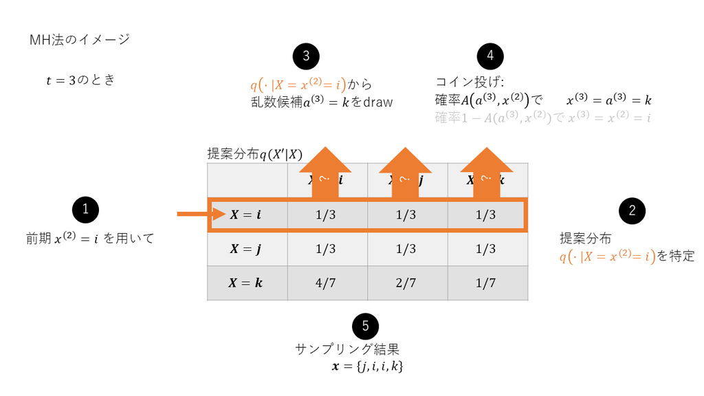

<例題> 定常分布は\({\bf \bar p} = (\frac{1}{6}, \frac{1}{2}, \frac{1}{3})\)でした. 詳細釣り合い条件を満たす遷移核はわかりません. なので適当に提案分布を一様分布にしてみます.

- 提案分布

|  | 紋 | 縞 | 玉 |
| --- | --- | --- | --- |
| 紋 | 1/3 | 1/3 | 1/3 |
| 縞 | 1/3 | 1/3 | 1/3 |
| 玉 | 1/3 | 1/3 | 1/3 |

MH法で定常分布\({\bf \bar p}\)に従う乱数を発生させてみましょう

```
## [1] "acceptance rate"
```

```
## [1] 0.7785455
```

```
## [1] "Run Time"
```

```
## Time difference of 2.377194 secs
```

```
## [1] "sampled distribution"
```

```
## [1] 0.16751 0.49850 0.33399
```

```
## [1] "invariant distribution"
```

```
## [1] 0.1666667 0.5000000 0.3333333
```

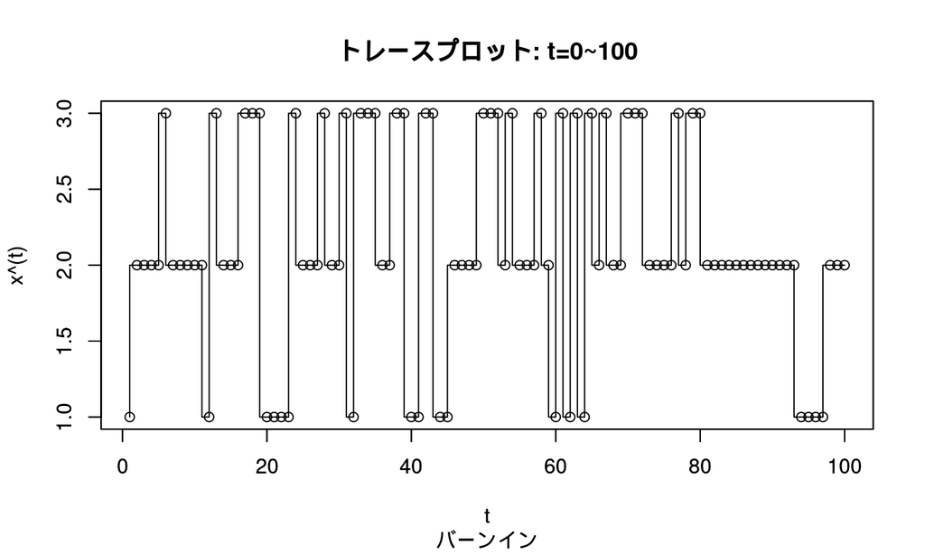

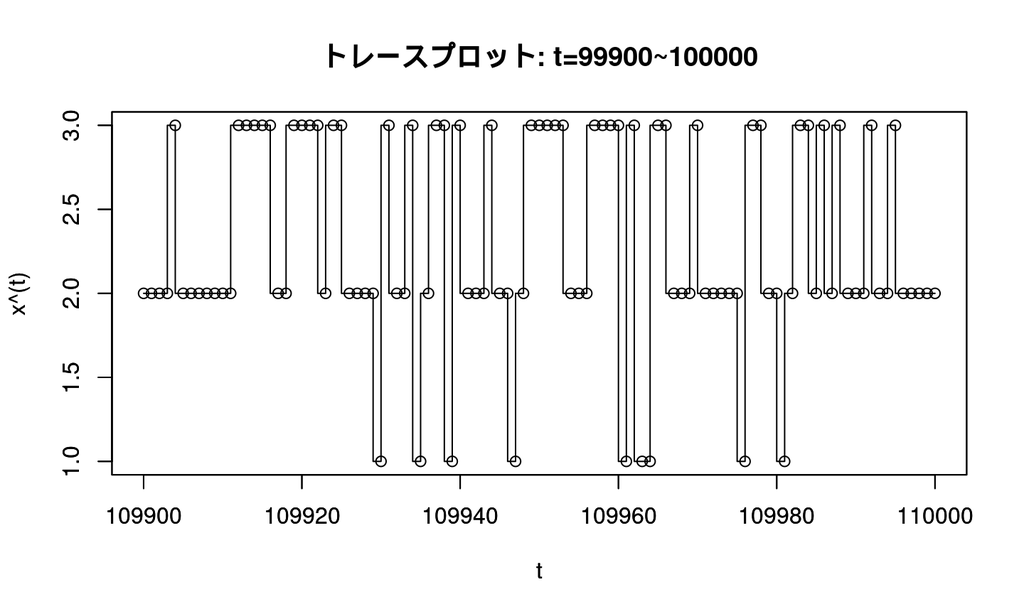

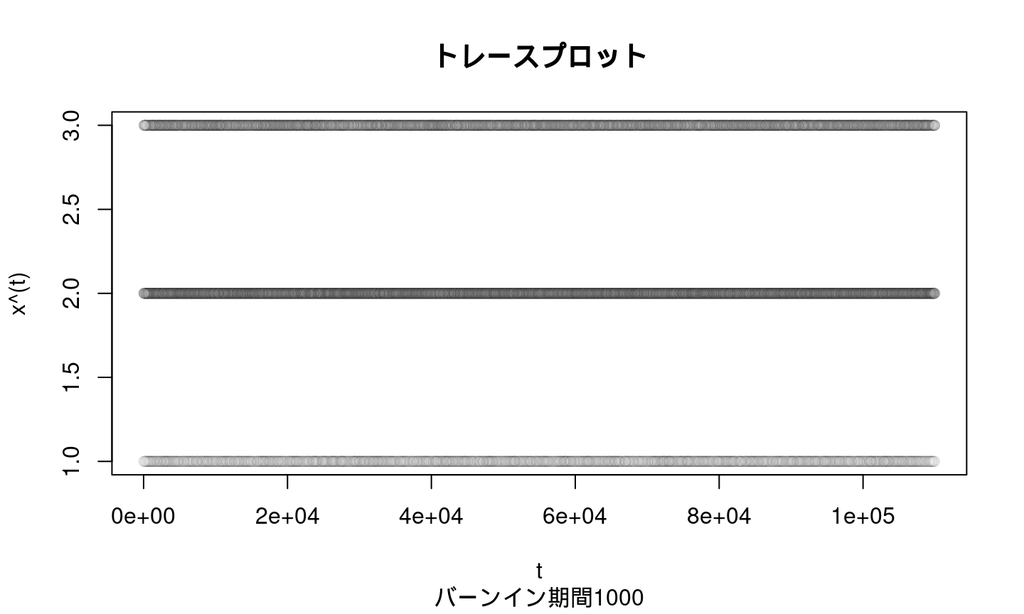

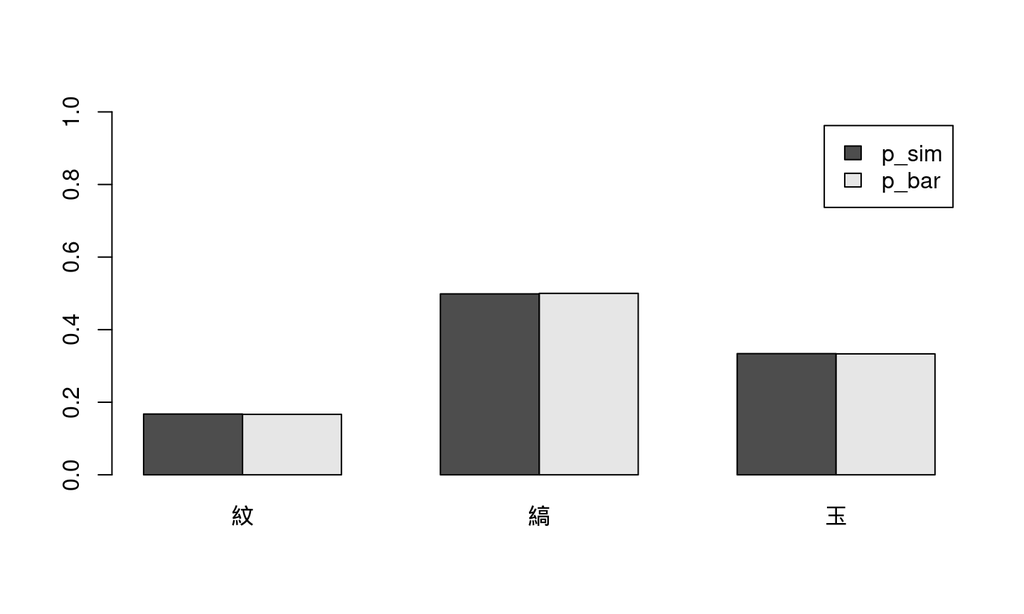

## 離散から連続へ

これまでは離散の例で, 確率変数\(X\)のとりうる値は\(\{紋, 縞, 玉\}\)の3つのみでした.  
私たちの目的は事後分布\(f(\theta|D)\)に従う連続の確率変数\(\theta\)(範囲は\((-\infty, \infty)\))の乱数を発生させることです.  
離散を連続に置き換えていきましょう.

- 定常分布

\[ \bar p(X) \rightarrow f(\theta|D) \]

- 提案分布

\[ q(a^{(t+1)}|X^{(t)}) \rightarrow q(a^{(t+1)}|\theta^{(t)}) \]

- 補正確率

\[\begin{eqnarray} A(a^{(t+1)}, X^{(t)}) &=& \min \left(1, \frac {q(X^{(t)}|a^{(t+1)}) \bar p(a^{(t+1)})} {q(a^{(t+1)}|X^{(t)}) \bar p(X^{(t)})} \right) \\ &\downarrow& \\ A(a^{(t+1)}, \theta^{(t)}) &=& \min \left(1, \frac {q(\theta^{(t)}|a^{(t+1)}) f(a^{(t+1)}|D)} {q(a^{(t+1)}|\theta^{(t)}) f(\theta^{(t)}|D)} \right) \\ &=& \min \left(1, \frac {q(\theta^{(t)}|a^{(t+1)}) \frac{f(D|a^{(t+1)})f(a^{(t+1)})}{f(D)} } {q(a^{(t+1)}|\theta^{(t)}) \frac{f(D|\theta^{(t)})f(\theta^{(t)})}{f(D)} } \right) \\ &=& \min \left(1, \frac {q(\theta^{(t)}|a^{(t+1)}) f(D|a^{(t+1)})f(a^{(t+1)}) } {q(a^{(t+1)}|\theta^{(t)}) f(D|\theta^{(t)})f(\theta^{(t)}) } \right) \\ \end{eqnarray}\]

## MH法の特殊形

今まで一般的なMH法を紹介してきましたが, ここからはMH法の特殊形(よりシンプル)を紹介します.

## 独立メトロポリス・ヘイスティングス法 (Independence Metropolis-Hastings: IMH)

一般的なMH法の提案分布は条件付きでした. \(q(\cdot|\theta^{(t)})\)  
IMH法は提案分布を1期前の乱数に依存しない無条件分布\(q(\cdot)\)とします. そうすると各ステップでdrawされる乱数の候補が互いに独立(\(i.i.d\))になります.

補正確率は以下のようになります

\[\begin{eqnarray} A(a^{(t+1)}, \theta^{(t)}) &=& \min \left(1, \frac {q(\theta^{(t)}) f(a^{(t+1)}|D)} {q(a^{(t+1)}) f(\theta^{(t)}|D)} \right) \\ \end{eqnarray}\]

<例題>

ポアソン分布のパラメータ(期待値)を推定します. ポアソン分布の尤度にガンマ分布の事前分布をかけて事後分布が\(f(\theta|\alpha=11,\lambda=13)\)のガンマ分布となりました. これに従う乱数をIMHで発生してみましょう.  
(ガンマ分布なら期待値と分散は解析的に求まっているのでわざわざMH法使わなくてもいけるのですが教材としてやってみます)

目的分布である事後カーネルは,

\[ f(D|\theta)f(\theta) = e^{-13\theta}\theta^{10} \]

提案分布\(q(\theta)\)は何でもいいですが, 簡単な正規分布\({\rm Normal}(1, 0.5)\)にしてみます. (実際ここの調整が難しいのですが)

```
## 解析解
## Mean[1] 0.846
## Var[1] 0.065
## SD[1] 0.255
```

```
## 採択率[1] 0.41231
```

```
## モンテカルロ積分
## Mean[1] 0.846
## Var[1] 0.066
## SD[1] 0.256
```

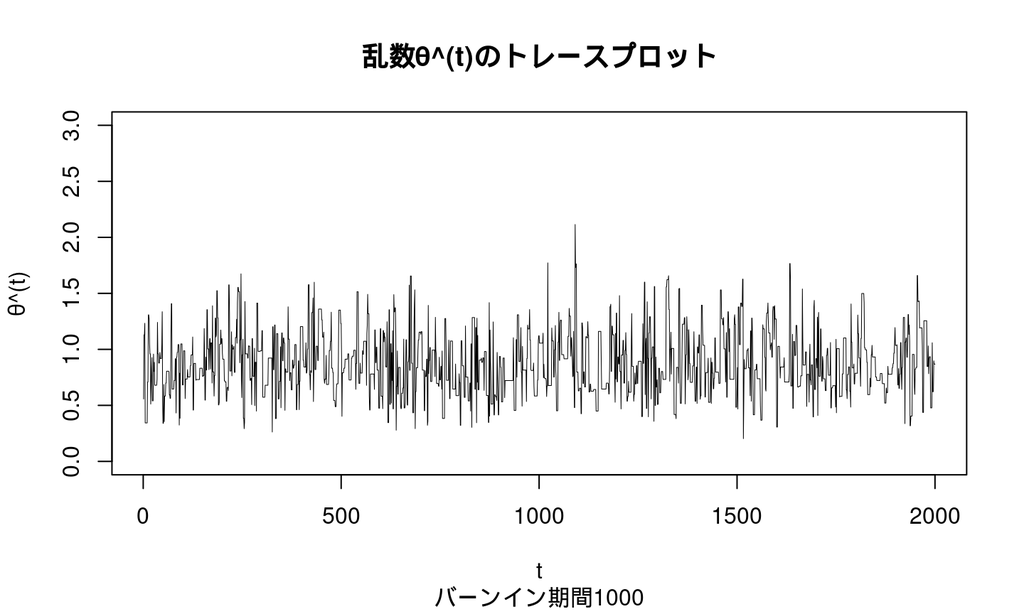

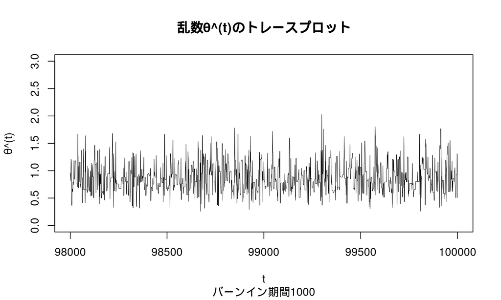

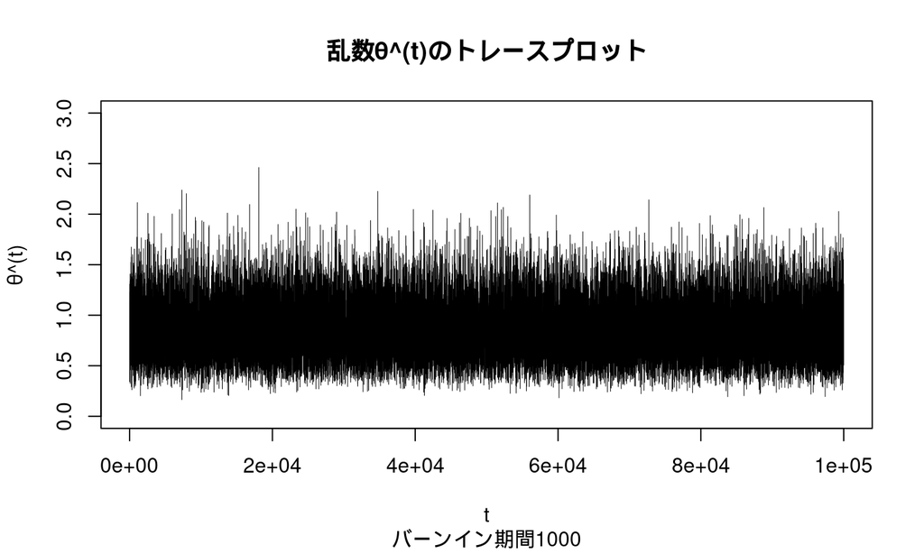

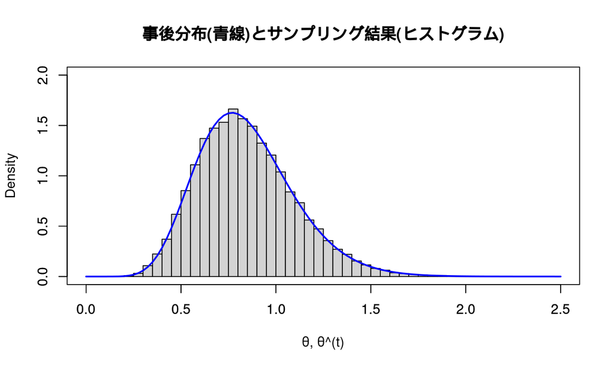

## IMH法の弱点

上の例では提案分布を\({\rm Normal}(1, 0.5)\)としてみました. 結果的には良いMCMCサンプリングができと言えます. その理由は, 目的分布である事後分布\({\rm Gamma}(\alpha=11, \lambda=13)\)と結構重なっていたからです.

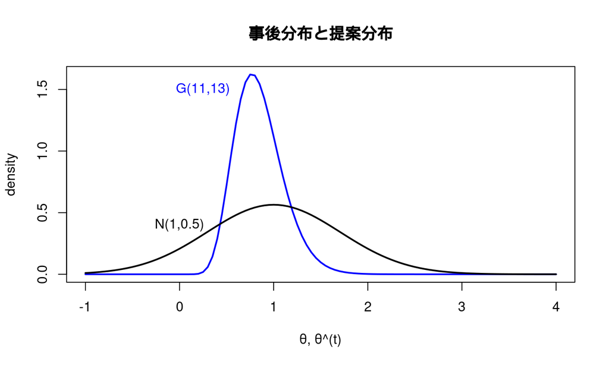

提案分布の期待値と分散を変えるとどうなるでしょう.

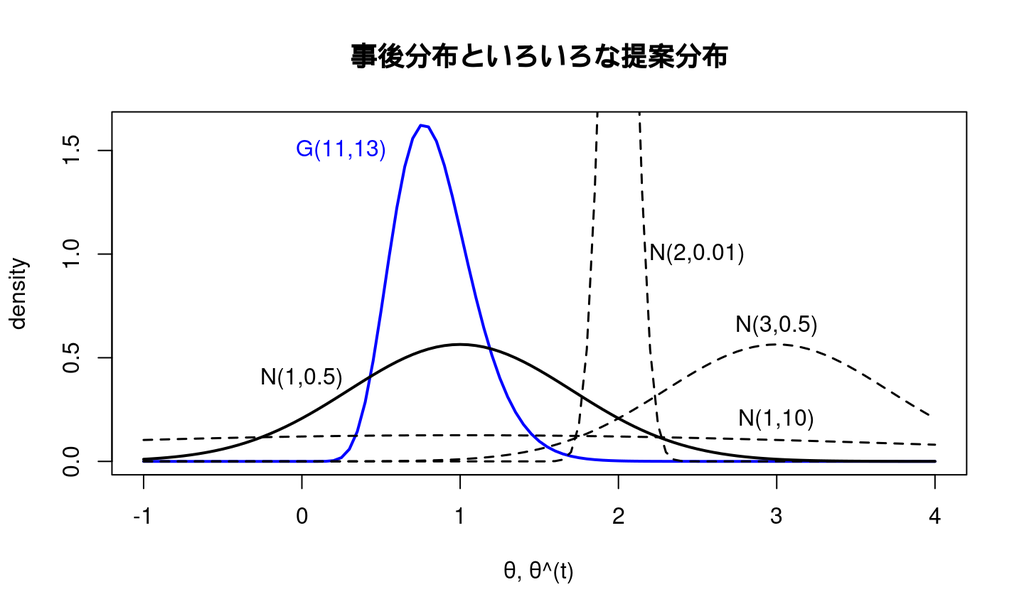

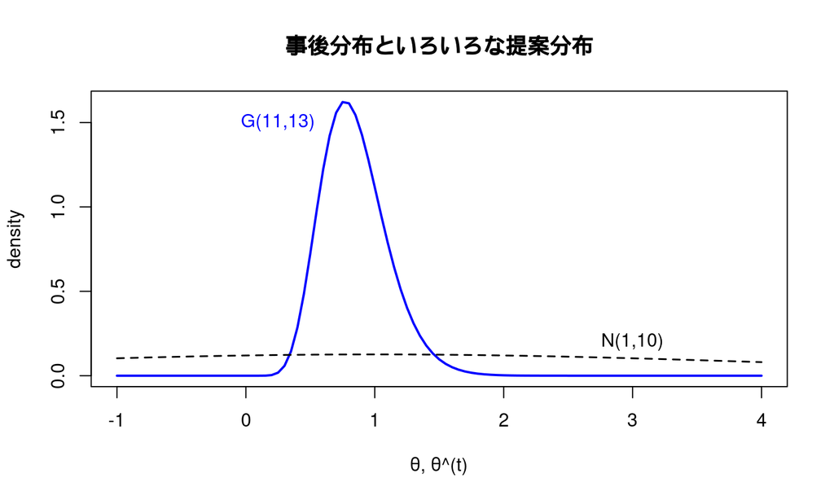

```
## 解析解
## Mean[1] 0.846
## Var[1] 0.065
## SD[1] 0.255
```

```
## [1] "proposal: N(1, 10)"
```

```
## 採択率[1] 0.09924
```

```
## モンテカルロ積分
## Mean[1] 0.845
## Var[1] 0.065
## SD[1] 0.256
```

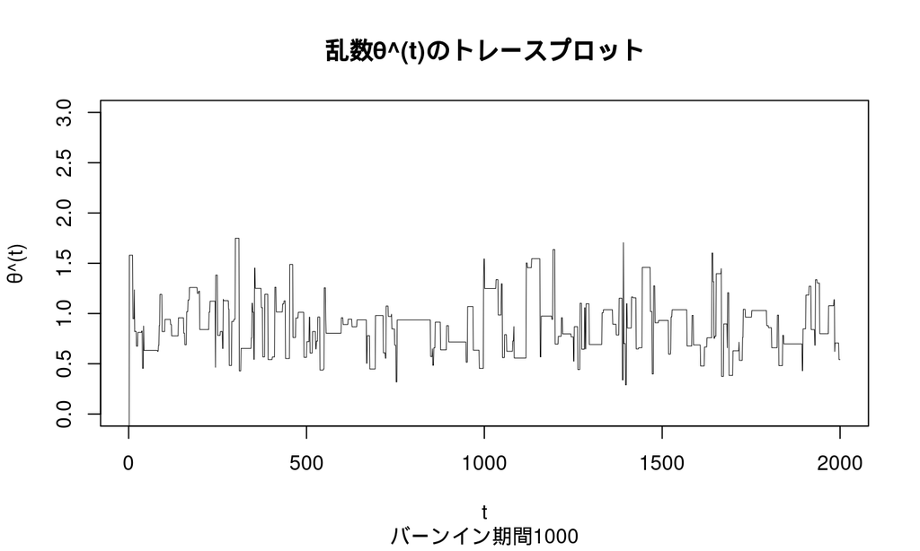

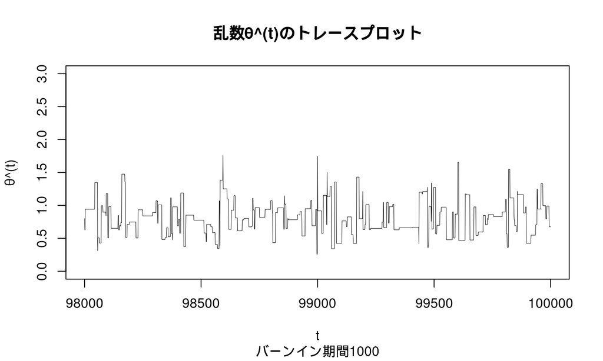

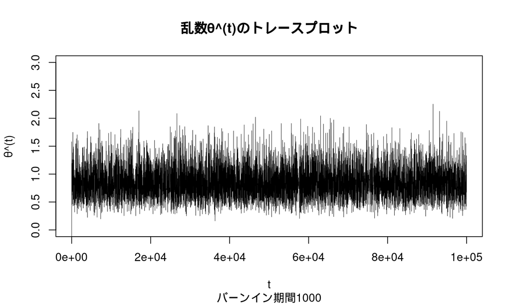